# Red Wine EDA

Several plot below drawn to find insight between features. First one is fixed acidity and citric acid

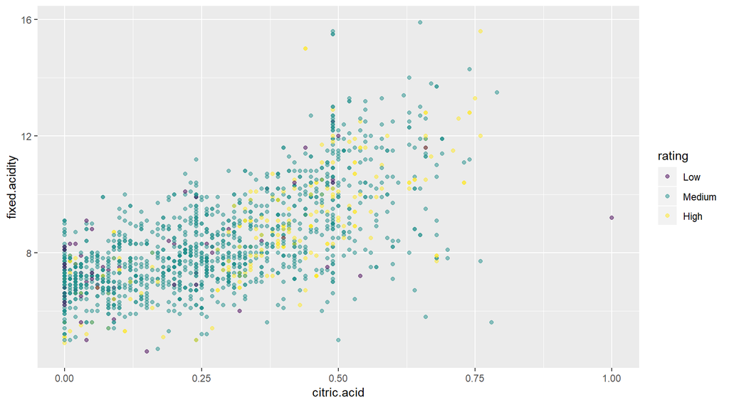

Although Fixed Acidity correlates highly with Citric Acid, the rating points could be anywhere in the plot so not much insight can be taken from this plot.

Next is between density and alcohol.

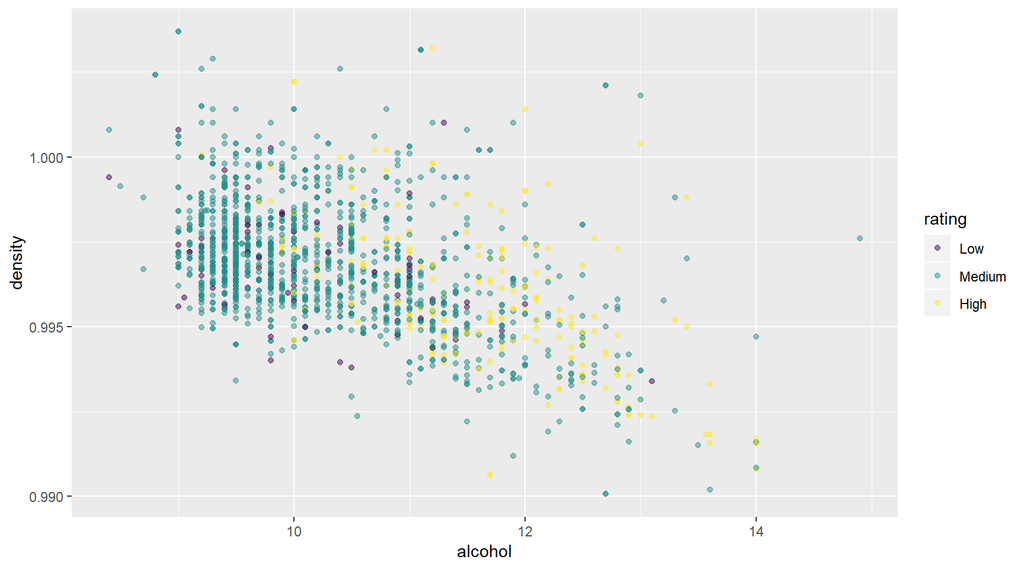

Again, not so much insights.

Move on to the alcohol and residual sugar.

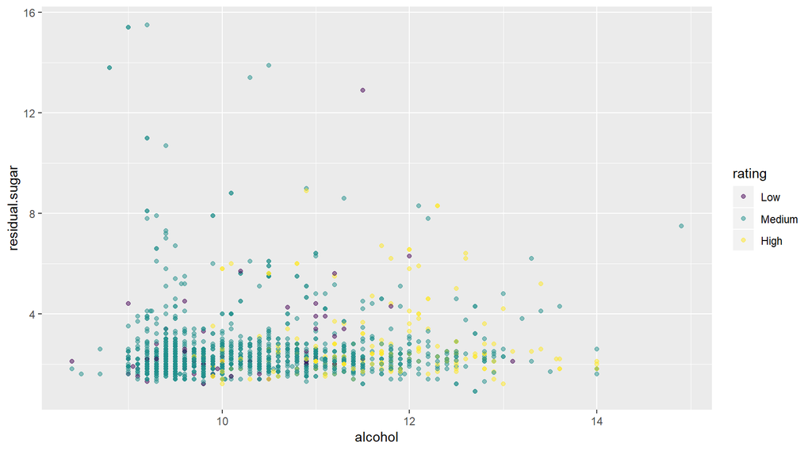

I think because of the low correlation between sugar and quality, when combined with alcohol, this plot also not showing much information.

The last I will be taking look at is between residual sugar and density.

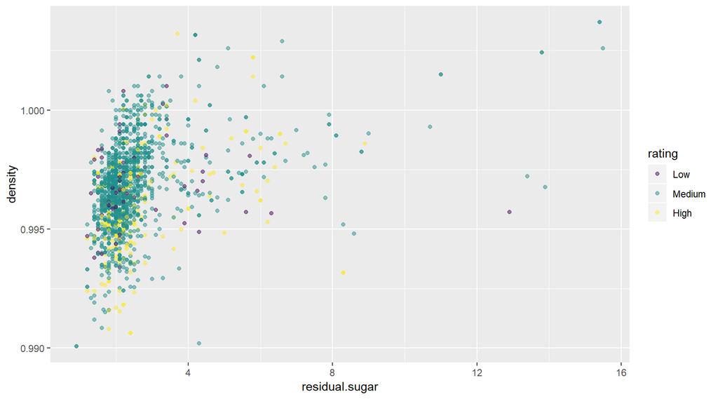

Nope. Not much can be taken from this plot.

## Multivariate Analysis

### Were there any interesting or surprising interactions between features?

Well I am actually a bit disappointed to see there is not so much to tell when comparing residual sugar, density, and alcohol. After all, the 4 features that relatively highly correlates to the alcohol that most explains what makes a quality wine low, medium and high.

# 3. Linear Model

Based on the plot I have drawn, I create a linear model to predict the wine quality based on the 4 features that correlates highly.

```
##
## Calls:
## m1: lm(formula = quality ~ alcohol, data = rw)
## m2: lm(formula = quality ~ alcohol + volatile.acidity, data = rw)
## m3: lm(formula = quality ~ alcohol + volatile.acidity + sulphates,
##     data = rw)
## m4: lm(formula = quality ~ alcohol + volatile.acidity + sulphates +
##     citric.acid, data = rw)
##
## ============================================================================
##                          m1            m2            m3            m4
## ----------------------------------------------------------------------------
##   (Intercept)           1.875***      3.095***      2.611***      2.646***
##                        (0.175)       (0.184)       (0.196)       (0.201)
##   alcohol               0.361***      0.314***      0.309***      0.309***
##                        (0.017)       (0.016)       (0.016)       (0.016)
##   volatile.acidity                   -1.384***     -1.221***     -1.265***
##                                      (0.095)       (0.097)       (0.113)
##   sulphates                                         0.679***      0.696***
##                                                    (0.101)       (0.103)
##   citric.acid                                                    -0.079
##                                                                  (0.104)
## ----------------------------------------------------------------------------
##   R-squared             0.227         0.317         0.336         0.336
##   adj. R-squared        0.226         0.316         0.335         0.334
##   sigma                 0.710         0.668         0.659         0.659
##   F                   468.267       370.379       268.912       201.777
##   p                     0.000         0.000         0.000         0.000
##   Log-likelihood    -1721.057     -1621.814     -1599.384     -1599.093
##   Deviance            805.870       711.796       692.105       691.852
##   AIC                3448.114      3251.628      3208.768      3210.186
##   BIC                3464.245      3273.136      3235.654      3242.448
##   N                  1599          1599          1599          1599
## ============================================================================
```

We can describe the model as:

**Wine Quality = 2.646 + 0.309(Alcohol) - 1.265(Volatile Acidity) + 0.696(Sulphates) - 0.079(Citric Acid)**

The model only limited to 4 features. I also think that this model is oversimplified because there are maybe other features that are not included in the analysis that correlates highly with other feature and the quality output.

# 4. Final Conclusion

## Plot One

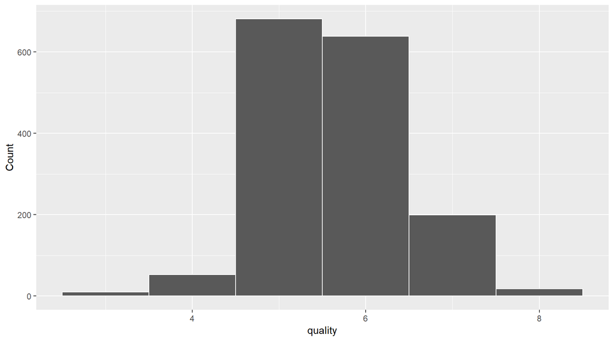

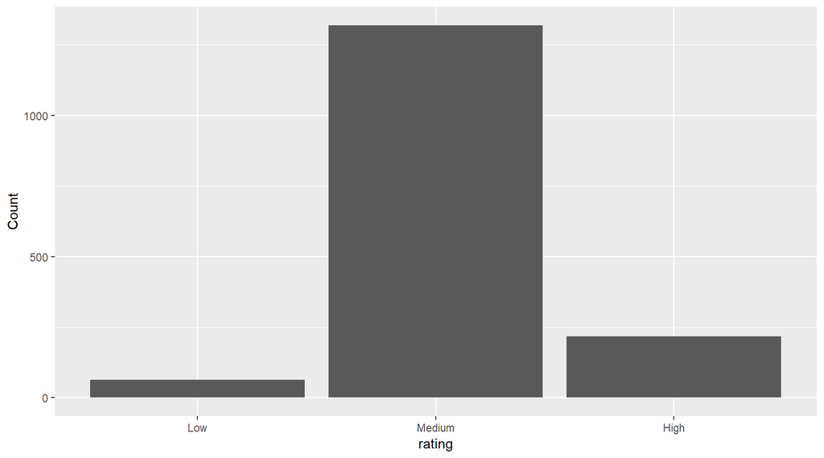

### Description One

From the Univariate Plot section, we can see that the data is imbalanced. Further method such as oversampling or undersampling can be used in the next analysis to deal with this problem.

## Plot Two

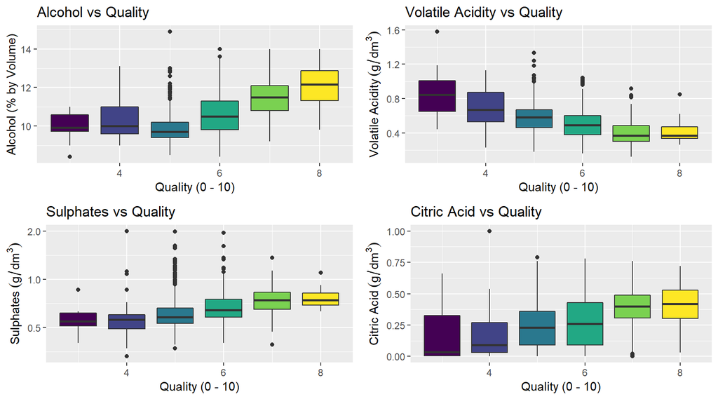

### Description Two

For the Bivariate Plot section, we can see the top 4 correlations between features and quality of the wine. We can also see that there are many outliers in the quality of 5. Maybe it is because that our data mainly fall in the Medium quality (5 and 6) so the chance of outliers would higher in that segment.

The interesting part is that for the quality 5 in Alcohol vs Quality, the boxplot shows that there is a slight decline. I think this happens because the boxplot didn’t include the outliers and there are so many outliers in this point. When we see at the overall points, the correlation between alcohol and quality is a consistent positive.

In the Volatile Acidity vs Quality plot shows a negative correlation. Ezekeil Neeley (2004) said that the production of volatile acidity (acetic acid) will result in the concomitant formation of other, sometimes unpleasant, aroma compounds. This explains the negative correlation between volatile acidity and quality of the wine.

The Sulphates vs Quality plot has a denser group of positive correlation of sulphates and quality.

The boxplot of Citric Acid vs Quality shows a wide range distribution. Even though the number of the data in the low rating (3 and 4) not as many as medium rating (5 and 6), the interquartile seems to be wide, especially in the quality of 3.

## Plot Three

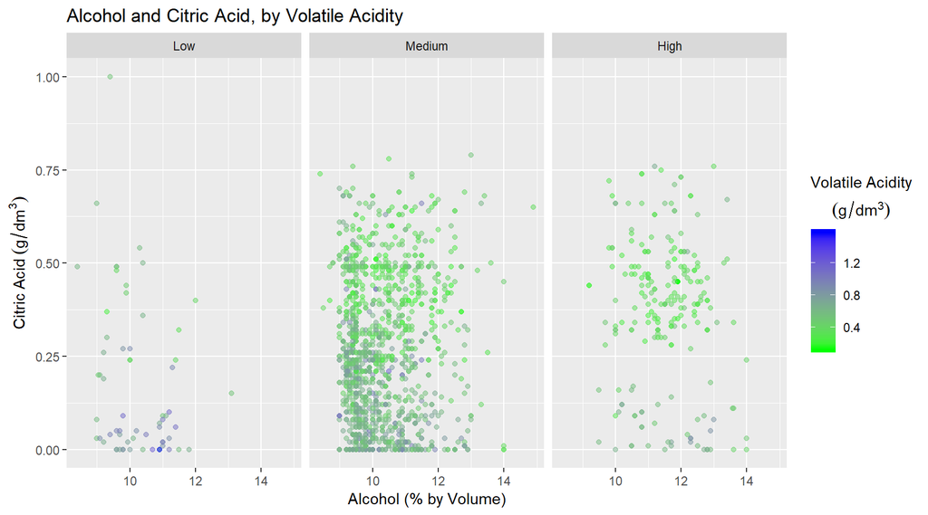

### Description Three

I love seeing this plot. This shows that alcohol, citric acid, and quality of the wine are highly linked. We can clearly see a pattern here where lower points of citric acid tends to group in the low quality section (also more blue in color of volatile acidity), and vice versa, higher points of citric acid tends to group in the high quality section (also more green in color of volatile acidity).

# 5. Reflection

Since I am new to R, I think the most struggling is with what feature I can draw a plot using R library. After finding some ways in the website, the next step is creating a story to explain the insights gained from the data. There are so many that I still have to learn in gaining more insights from data like dealing with imbalanced data, create a model based on correlation, and explore what other features can be added to the analysis.

For futher analysis, I think it would be more interesting to add some features of wine making. Wine is a complex drink and adding more features, such as age of the wine, average temperature of the storage of the wine, and maybe even as far as time in picking the grapes would add a great analysis to the Red Wine EDA. Overall, this is a great experience for me and I am excited to explore more and dive deeper into the world of Data Science.

Big thanks to Darui Zhang, because I get most of the inspiration from his knit. You can see his work in the website.

https://github.com/Dalaska/Udacity-Red-Wine-Quality

# References:

1. https://www.etslabs.com/analyses/DEN
2. https://stackoverflow.com/questions/6957549/overlaying-histograms-with-ggplot2-in-r
3. https://www.statmethods.net/advgraphs/ggplot2.html
4. https://cran.r-project.org/web/packages/BBmisc/BBmisc.pdf
5. https://waterhouse.ucdavis.edu/whats-in-wine/volatile-acidity
6. https://wineserver.ucdavis.edu/industry-info/enology/methods-and-techniques/common-chemical-reagents/citric-acid